[GitHub](https://github.com/Janssena/DeepCompartmentModels.jl)[](https://github.com/Janssena/DeepCompartmentModels.jl/blob/main/tutorials/03-universal-diffeq.qmd)

# Universal Differential Equations

*Discovering an unknown elimination process with a hybrid ODE + neural network*

In a standard deep compartment model the neural network predicts the *parameters* of an ODE. In a **universal differential equation** (UDE) the neural network is *part of the ODE*: it replaces a term of the right-hand side that is not known. For the models in this package that right-hand side is

```
dA/dt = [I, 0, ..., 0] + NN(A; θ)
```

where `I` is the infusion rate that the dosing callback sets for the individual, and the network learns the remaining dynamics from the data. This tutorial simulates a drug with saturable (Michaelis-Menten) elimination and learns the elimination curve from amount-time data.

## Setup

```julia
using DeepCompartmentModels   # also re-exports Lux, Optimisers, OrdinaryDiffEq, ...
using CairoMakie
using Random
```

## Simulate data

```julia
function true_ode!(dA, A, p, t)
    Vmax, Km, I = p
    dA[1] = I - Vmax * A[1] / (Km + A[1])
end

rng = Random.Xoshiro(1)
t_obs = Float32[0.5, 1, 2, 4, 6, 8, 12, 16, 24]

population = Population(map(1:12) do i
    dose = Float32(50 + 25 * (i % 4))
    callback = generate_dosing_callback(Float32[0 dose], Float32)

    prob = ODEProblem(true_ode!, Float32[0], (-0.1f0, 24f0), Float32[8, 20, 0])
    sol = solve(prob, Tsit5(); callback, saveat = t_obs, tstops = callback.condition.times)
    y = max.(only.(sol.u) .+ 0.5f0 .* randn(rng, Float32, length(t_obs)), 0f0)

    Individual(i, Float32[1], t_obs, y, callback, Float32)
end)
```

```
12-element Population{BasicIndividual{Float32}}:
 BasicIndividual{Float32}(id = 1, ...)
 BasicIndividual{Float32}(id = 2, ...)
 BasicIndividual{Float32}(id = 3, ...)
 BasicIndividual{Float32}(id = 4, ...)
 BasicIndividual{Float32}(id = 5, ...)
 BasicIndividual{Float32}(id = 6, ...)
 BasicIndividual{Float32}(id = 7, ...)
 BasicIndividual{Float32}(id = 8, ...)
 BasicIndividual{Float32}(id = 9, ...)
 BasicIndividual{Float32}(id = 10, ...)
 BasicIndividual{Float32}(id = 11, ...)
 BasicIndividual{Float32}(id = 12, ...)
```

## Define the UDE

A `UniversalDiffEq` holds the structure of the ODE; the network goes in the `DeepCompartmentModel`. `UniversalDiffEq(1)` is a system with a single state. The network takes the state as its input and returns the rate of change that is not accounted for by the dose. Because that is the *elimination*, the network has to learn a negative number, so its last layer has no activation function.

```julia
ude = UniversalDiffEq(1)

nn = Lux.Chain(
    Lux.Dense(1, 16, tanh),
    Lux.Dense(16, 16, tanh),
    Lux.Dense(16, 1),
)

dcm = DeepCompartmentModel(ude, nn)
```

```
DeepCompartmentModel{ude = BasicUDE(), error = ImplicitError}
```

Note

The `sensealg` of the model decides how gradients are propagated through the ODE solver. For small networks (fewer than ~250 parameters) forward-mode sensitivities (`ForwardDiffSensitivity`) are fastest; for larger networks an adjoint method scales better. `DeepCompartmentModel` picks `GaussAdjoint(; autojacvec = ReverseDiffVJP(false))` for larger UDEs, and you can always pass your own with `sensealg = ...`. Avoid the compiled `ReverseDiffVJP(true)`: it is slower here, and a compiled tape is only valid when the right-hand side has no branches that depend on the values of the states or parameters. `InterpolatingAdjoint(; autojacvec = EnzymeVJP())` is faster still, but compiles for longer.

## Initialise and fit

`setup` creates the parameters `ps` and the (Lux) state `st`. For a UDE the network weights live in `ps.theta`, together with the infusion rate `I`, which the dosing callback manages (it is never trained).

```julia
obj = SSE()
ps, st = setup(obj, rng, dcm)
keys(ps.theta)
```

```
(:layer_1, :layer_2, :layer_3, :I)
```

`fit` minimises the objective with an Optimisers.jl rule. It returns the optimiser state, the trained parameters and the state, and calls `callback(epoch, loss)` every epoch. `parallel = :individual` solves the individuals on separate threads (start Julia with `-t auto` to benefit).

```julia
losses = Float32[]
opt_state, ps, st = fit(obj, dcm, population, Optimisers.Adam(3f-3), ps, st;
    epochs = 800,
    parallel = :individual,
    callback = (epoch, loss) -> push!(losses, loss),
)

println("SSE: ", round(first(losses), digits = 1), " -> ", round(last(losses), digits = 1))
```

```
SSE: 412503.9 -> 291.7
```

`fit` is a thin wrapper, there is no hidden magic. The call above is equivalent to this loop, which you can use directly if you need more control (for example custom learning rate schedules, early stopping or extra logging):

```julia
opt_state = Optimisers.setup(Optimisers.Adam(3f-3), ps)

for epoch in 1:800
    ∇ = gradient(obj, dcm, population, ps, st; parallel = :individual)   # gradient of the objective w.r.t. ps
    opt_state, ps = Optimisers.update(opt_state, ps, ∇)                  # one optimiser step
end
```

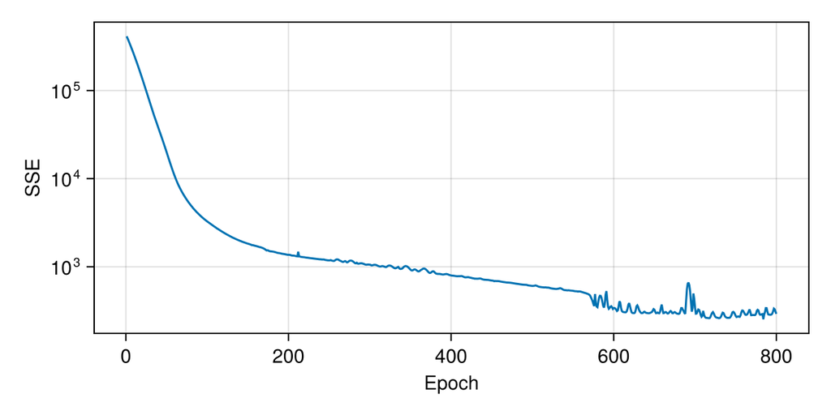

```julia
fig = Figure(size = (600, 300))
ax = Axis(fig[1, 1]; xlabel = "Epoch", ylabel = "SSE", yscale = log10)
lines!(ax, losses)
fig
```

## Predictions

`predict` solves the UDE for an individual (or a population) and returns the predicted observations. Pass `saveat` for a dense time grid.

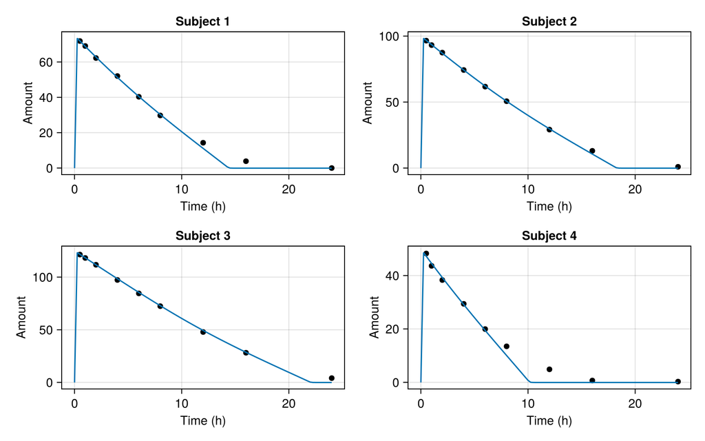

```julia
t_grid = collect(0f0:0.25f0:24f0)

fig = Figure(size = (800, 500))
for (i, indv) in enumerate(population[1:4])
    row, col = divrem(i - 1, 2)
    ax = Axis(fig[row + 1, col + 1]; title = "Subject $(indv.id)", xlabel = "Time (h)", ylabel = "Amount")
    scatter!(ax, get_t(indv), get_y(indv); color = :black)
    lines!(ax, t_grid, predict(dcm, indv, ps, st; saveat = t_grid))
end
fig
```

## Inspect the learned elimination

Since the network is the elimination term, we can evaluate it directly and compare it to the truth. `Lux.StatefulLuxLayer` binds the state of the network so that it can be called as a function of the input and the parameters.

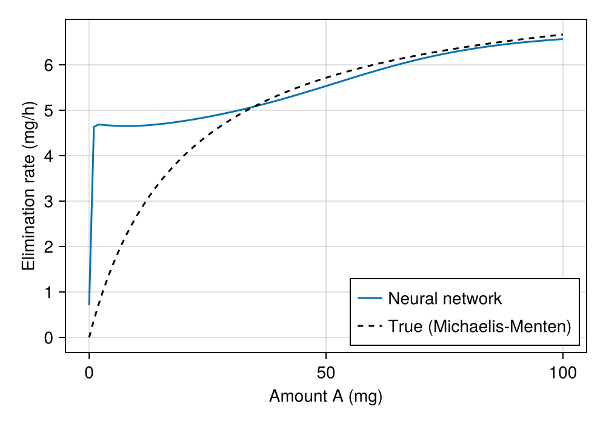

```julia
nn_fit = Lux.StatefulLuxLayer{true}(nn, nothing, st.theta)

amounts = collect(0f0:1f0:100f0)
learned = -vec(nn_fit(reshape(amounts, 1, :), ps.theta))
truth = @. 8f0 * amounts / (20f0 + amounts)

fig = Figure(size = (500, 350))
ax = Axis(fig[1, 1]; xlabel = "Amount A (mg)", ylabel = "Elimination rate (mg/h)")
lines!(ax, amounts, learned; label = "Neural network")
lines!(ax, amounts, truth; color = :black, linestyle = :dash, label = "True (Michaelis-Menten)")
axislegend(ax; position = :rb)
fig
```

After 800 epochs the network follows the saturating shape and is close to the truth at high amounts, but it is still off at low amounts (below ~30 mg), and the SSE is still well above the noise level of the simulation. Training for longer brings the curves closer together. Outside the range of amounts that occur in the data, for example close to zero, the network extrapolates and should not be trusted.

Note

In this model the network is shared by everyone: there are no individual parameters or random effects inside the ODE. All subjects therefore have the same elimination curve, which is why the simulated subjects here differ only in their dose.

## Summary

- `UniversalDiffEq(n)` + a Lux network in `DeepCompartmentModel` gives a hybrid ODE in which the network learns the dynamics that are not known.
- `setup`, `fit`, `gradient`, `predict` and the objectives (`SSE`, `MSE`, `LogLikelihood`) work as for any other model in the package; the weights live in `ps.theta`.
- Use `type = TimeConcatUDE()` to give the network the time as an extra input, and `inplace = true` for an in-place right-hand side.